# Weibull Gaps Simulation

Lacey Etzkorn

2/2/2020

# Model Formulation

$$\begin{align}
&& \textbf{EM Algorithm}
&& \textbf{Frailty Pack}
&&& \textbf{Difference}
\\
&\text{Frailty}
& w_i \sim N(0,\sigma^2)
&& \exp(v_i) \sim LN(1,\theta)
&&& \text{Frailties are centered around different constants.}
\\
&&&&&&& v_i \sim N(-\sigma^2/2, \sigma^2), \sigma^2 = \ln(\theta + 1) \Rightarrow w_i = v_i + \sigma^2/2
\\
&\text{Density}
& f(y) = b_i k y^{k-1} \exp( - b_i \cdot y^k)
&& f(y) = h_i^{-k} k y^{k-1} \exp( - h_i^{-k} \cdot y^k)
&&& b_i = h_i^{-k}
\\
\\
& \text{Hazard}
& \lambda(y) = b_i k y^{k-1}
&& \lambda(y) = h_i^{-k} k y^{k-1}
\\
\\
&\text{Survivor}
&S(y) = \exp( - b_i \cdot y^k)
&&S(y)= \exp( - h_i^{-k} \cdot y^k)
\\
\\
&\text{R. Predictor}
& b_{xi} = \exp(X_i \beta_x + w_i)
&& h_{ix}^{-k} = \exp(X_i \beta_x + \ln(v_i))
&&& \text{Interpretation of }\beta_{x0} \text{ will vary. } \beta_{EMx0} \approx \beta_{FPx0} - \sigma^2/2
\\
\\
&\text{T. Predictor}
& b_{yi} = \exp(X_i \beta_y + \alpha w_i)
&& h_{yi}^{-k_y} = \exp(X_i \beta_y + \alpha \ln(v_i))
&&& \text{Interpretation of }\beta_{y0} \text{ will vary. } \beta_{EMy0} \approx \beta_{FPy0} - \alpha \sigma^2/2
\\
\\
\end{align}$$

# Generate Parameter Grid

Here we create a grid of parameter values over which to simulate data. For now, we only generate one simulated data set per parameter combination.

```r
par.grid <-
expand.grid(beta.d0 = c(0, .1), beta.dtrt = c(0, .25),
    beta.x0 = c(.5, 1), beta.xtrt = c(0, .25),
                   kd = c(1, 1.5), kx = c(1, 1.5), theta = c(.05, .1), alpha = c(0, 1))
truth <- par.grid %>%
gather("par", "truth") %>% distinct
head(par.grid, 10)
```

```
##    beta.d0 beta.dtrt beta.x0 beta.xtrt kd kx theta alpha
## 1      0.0      0.00     0.5      0.00  1  1  0.05     0
## 2      0.1      0.00     0.5      0.00  1  1  0.05     0
## 3      0.0      0.25     0.5      0.00  1  1  0.05     0
## 4      0.1      0.25     0.5      0.00  1  1  0.05     0
## 5      0.0      0.00     1.0      0.00  1  1  0.05     0
## 6      0.1      0.00     1.0      0.00  1  1  0.05     0
## 7      0.0      0.25     1.0      0.00  1  1  0.05     0
## 8      0.1      0.25     1.0      0.00  1  1  0.05     0
## 9      0.0      0.00     0.5      0.25  1  1  0.05     0
## 10     0.1      0.00     0.5      0.25  1  1  0.05     0
```

# Generate Data Sets and Fit Models

```r
if(!file.exists("simulation_frame_021829.rdata")){
    # generate simulated data set for each parameter combination
    d <- par.grid %>%
    mutate(i = 1:n()) %>%
    nest(-i) %>%
    rename(parameters = data) %>%
    mutate(simulated.data = map(parameters, ~simulate.data(par0 = unlist(.), n = 200, frailty.center = "hazard")))

    # fit model on each of the data sets
    d$model = map(d$simulated.data,
          ~weibull.gap.model(data = ., covar.names = "trt",
                   e.iter = 400, m.iter = 1, frailty.center = "hazard"))
    d$model.linear = map(d$simulated.data,
          ~weibull.gap.model(data = ., covar.names = "trt",
                   e.iter = 400, m.iter = 1, frailty.center = "linear"))
    #d$model = map(d$model,
    #     ~weibull.gap.model(add = T, model = ., covar.names = "trt",
    #              e.iter = 200, m.iter = 1, frailty.center = "hazard"))

    # fit frailtypack on each data set
    d$frailtypack = map(d$simulated.data,
    ~frailtypack::frailtyPenal(
        data = .,
        formula = Surv(g, event) ~ trt + cluster(id) + terminal(terminal),
        formula.terminalEvent = ~ trt,
        hazard = "Weibull",
        recurrentAG = F,
        RandDist = "LogN",
        print.times = F))

    save(d, file = "simulation_frame_021829.rdata")
}else load(file = "simulation_frame_021829.rdata")
```

# Plot Model Convergence

We plot the trajectory of fits for each parameter across all models. Each plot represents a mixture of two true values that generated the data, represented by two red lines.

### Centered on Hazard Scale

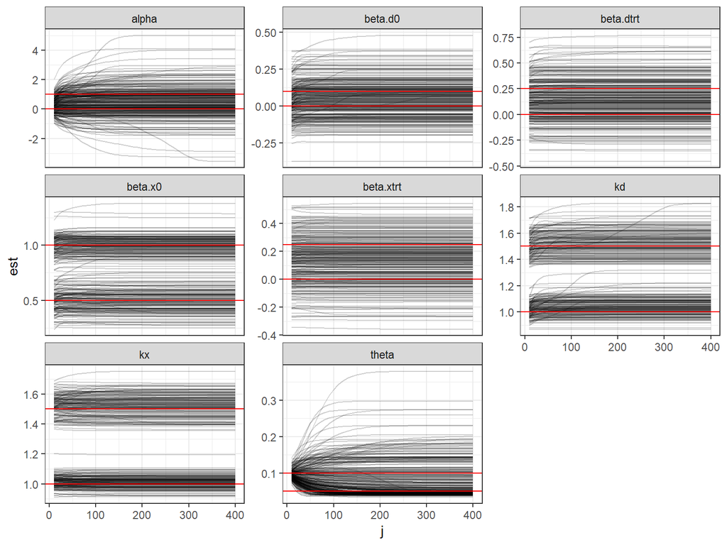

### Centered on Linear Scale

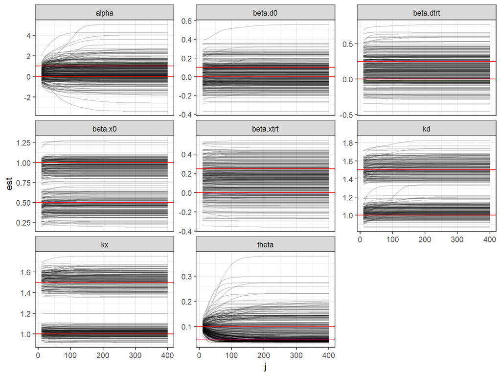

# Empirical Estimator Characteristics

```
##          par truth   correct           m         bias         mse
## 1      alpha  0.00 0.6171875 0.002066959 -0.002066959 0.780650833
## 2      alpha  1.00 0.4609375 0.952557223  0.047442777 1.176031837
## 3    beta.d0  0.00 0.9453125 0.002307579 -0.002307579 0.012536829
## 4    beta.d0  0.10 0.9062500 0.097249866  0.002750134 0.015839064
## 5  beta.dtrt  0.00 0.9296875 0.013455977 -0.013455977 0.024208984
## 6  beta.dtrt  0.25 0.9062500 0.268357469 -0.018357469 0.030553861
## 7    beta.x0  0.50 0.8750000 0.502394789 -0.002394789 0.015274774
## 8    beta.x0  1.00 0.9453125 1.006694742 -0.006694742 0.007686873
## 9  beta.xtrt  0.00 0.9609375 0.005157954 -0.005157954 0.015665017
## 10 beta.xtrt  0.25 0.9531250 0.256635235 -0.006635235 0.013525560
## 11        kd  1.00 0.8750000 1.044464236 -0.044464236 0.007552256
## 12        kd  1.50 0.9453125 1.531884841 -0.031884841 0.010850568
## 13        kx  1.00 0.9296875 1.010792960 -0.010792960 0.002023158
## 14        kx  1.50 0.9531250 1.524580405 -0.024580405 0.006633656
## 15     theta  0.05 0.5234375 0.068203747 -0.018203747 0.001907189
## 16     theta  0.10 0.1953125 0.105144327 -0.005144327 0.003875626
```

The column `correct` gives the proportion of confidence intervals containing the true value of the parameter. We see that our confidence intervals for alpha and theta do not contain nearly 95% of the observations. It is unclear whether this is a problem with the asymptotic assumption (we are only using 200 individuals per data set) or true bias in the MLE.

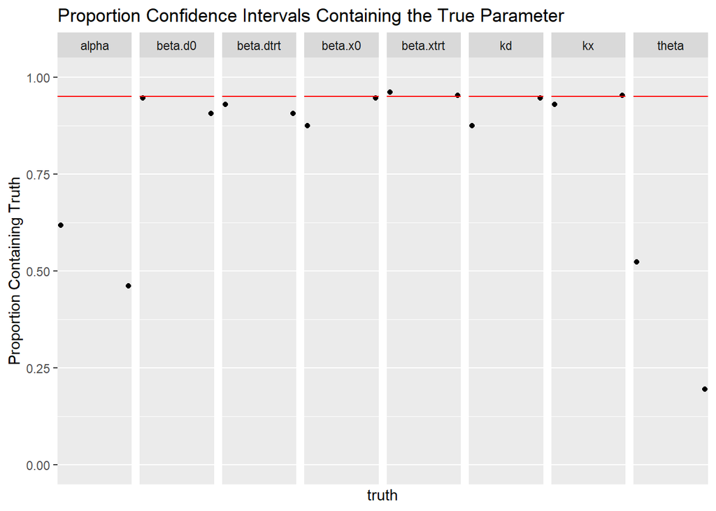

# FrailtyPack Comparison

```r
# fit model on each of the data sets
d$fp.coef <- map(d$frailtypack, ~extract.fp.coef(.,center = "hazard"))
d$fp.fail <- map(d$frailtypack, ~ !is.numeric(.$linear.pred)) %>% unlist
table(d$fp.fail)
```

```
##
## FALSE  TRUE
##   240    16
```

### Warning Message

For some reason, markdown isn’t liking this bit of code, though it doesn’t return an error when I run it manually. It just gives a warning.

```r
frailtyPenal(data = d$simulated.data[[min(which(d$fp.fail))]],
        formula = Surv(g, event) ~ trt + cluster(id) + terminal(terminal),
        formula.terminalEvent = ~ trt,
        hazard = "Weibull",
        recurrentAG = F,
        RandDist = "LogN",
        print.times = F)
```

The warning message is “Problem in the loglikelihood computation. The program stopped abnormally. Please verify your dataset.”

### Set Different Starting Values

The model DOES run when I set starting values for the regression coefficients.

```r
frailtyPenal(data = d$simulated.data[[min(which(d$fp.fail))]],
        formula = Surv(g, event) ~ trt + cluster(id) + terminal(terminal),
        formula.terminalEvent = ~ trt,
        hazard = "Weibull",
        recurrentAG = F,
        RandDist = "LogN",
        print.times = F, init.B = c(0,0.25))
```

### Data Set characteristics

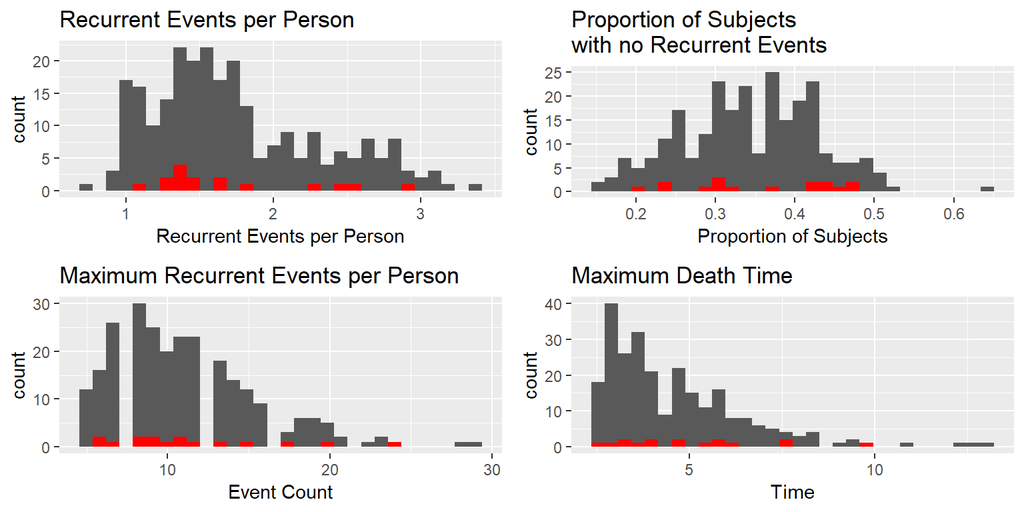

### Compare to FrailtyPack (Hazard-Centered Frailty Model)

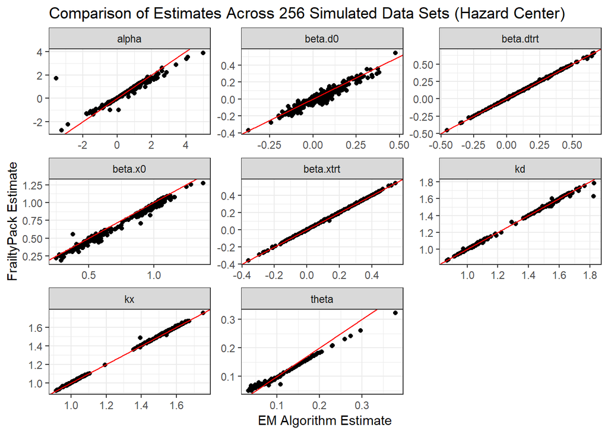

### Compare to Frailtypack: Linear-Centered Frailties

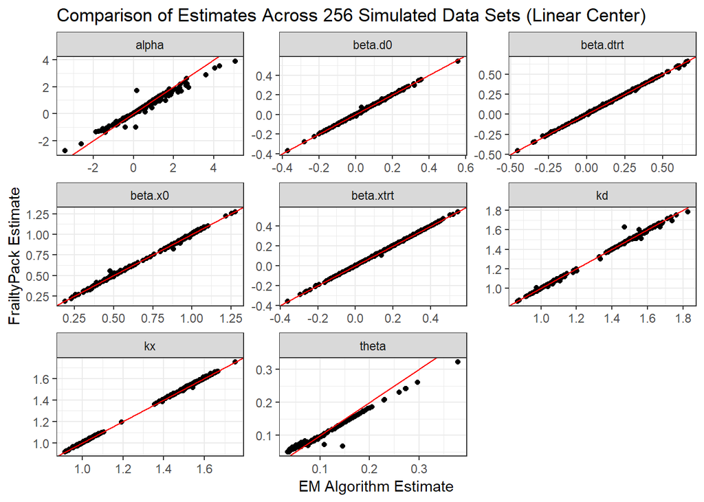

# Demonstration that normal random effect specifications are “kind of” equivalent

## Compare Random Effect Estimates

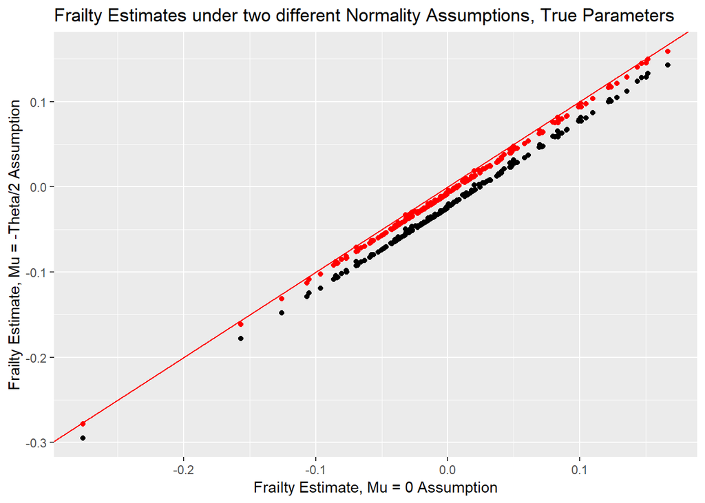

```r
if(!file.exists("Frailty_Center_Comparison_021020.rdata")){
    par0 = unlist(d$parameters[[1]])
    df1 <- simulate.data(par0 = par0, n = 200)
    df1 <- expected.frailty(df = df1, phi = par0,
            f.w = list(Ew = function(w, phi) w), covar.names = "trt", frailty.center = "linear")
    df2 <- expected.frailty(df = df1, phi = par0,
            f.w = list(Ew = function(w, phi) w), covar.names = "trt", frailty.center = "hazard")
    test <- weibull.gap.model(data = df1, covar.names = "trt",e.iter = 300, m.iter = 1, frailty.center = "linear")
    test2 <- weibull.gap.model(data = df1, covar.names = "trt",e.iter = 300, m.iter = 1, frailty.center = "hazard")
    save(par0, df1, df2, test, test2, file = "Frailty_Center_Comparison_021020.rdata")
}else load("Frailty_Center_Comparison_021020.rdata")
ggplot() +
geom_point(aes(x = df1$Ew, y = df2$Ew)) +
geom_point(aes(x = df1$Ew, y = df2$Ew + test2$estimates["theta"]/2), color = "red") +
geom_abline(slope = 1, intercept = 0, color = "red") +
xlab("Frailty Estimate, Mu = 0 Assumption")+
ylab("Frailty Estimate, Mu = -Theta/2 Assumption") +
ggtitle("Frailty Estimates under two different Normality Assumptions, True Parameters")
```

We see that the estimated frailties (given the true parameters) are nearly exactly the same under the two different normality assumptions, except perhaps a constant shift. This is because the frailties are being penalized toward different constants. We can also see that the empirical variance of the frailties are nearly the same:

```r
var(df1$Ew); var(df2$Ew); var(df1$w)
```

```
## [1] 0.004707994
```

```
## [1] 0.004747312
```

```
## [1] 0.03704699
```

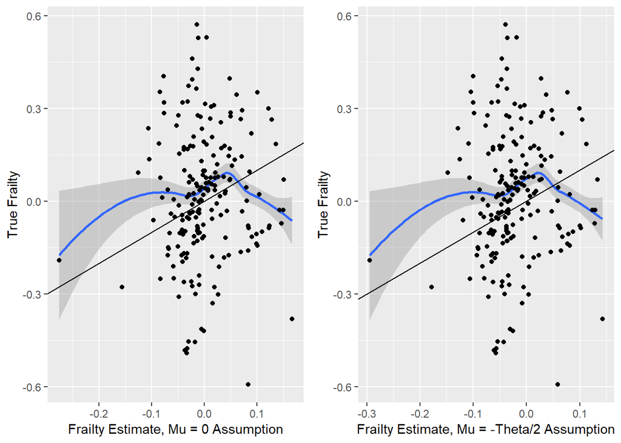

## Compare Model Fits

```
##         beta.d0 beta.dtrt beta.x0 beta.xtrt    kd    kx theta alpha
## truth     0.000     0.000   0.500     0.000 1.000 1.000 0.050  0.00
## linear0   0.030     0.400   0.660    -0.022 1.447 1.018 0.033  5.74
## hazard1   0.094     0.382   0.671    -0.023 1.390 1.017 0.033  5.30
```

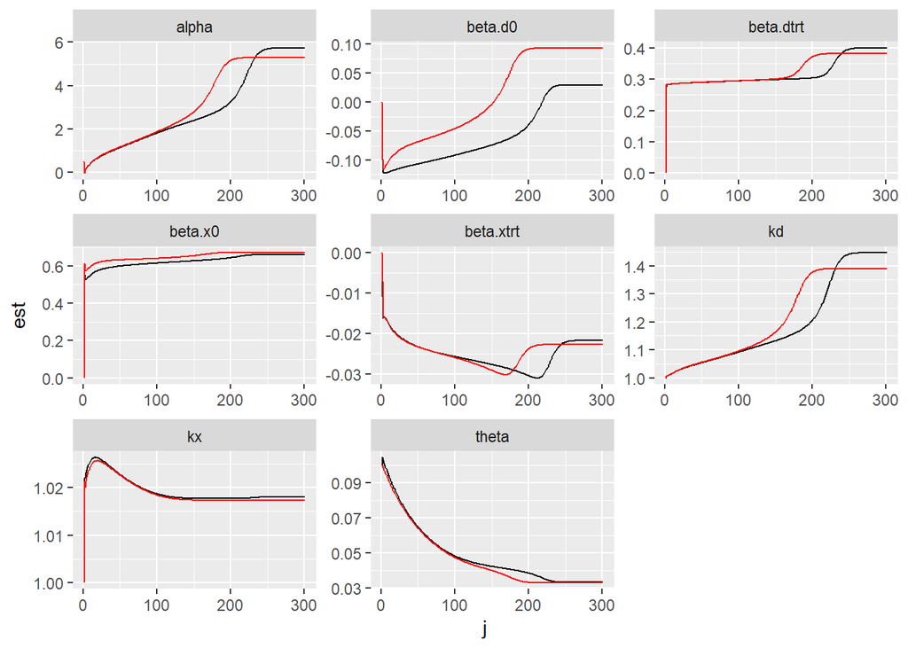